# ML Entrepreneurship - Project 2

# Predicting Earthquakes with Google Maps

## What's Our Goal?

In our second ML-to-WebApp project, we are going to build an earthquake forecasting tool using live earthquake data from the [USGS Earthquake Hazards Program](https://earthquake.usgs.gov/) and [Google Maps API](https://cloud.google.com/maps-platform/).

We will start by doing some exploratory data analysis (EDA) on the earthquakes-feed data along with some geo-based and rapid mapping techniques. We will apply feature engineering and aggregation techniques to limit the scope of the web application.

We will then design a model based around the belief of [cyclicality around deeper earthquakes](https://www.earthmagazine.org/article/superquakes-supercycles-and-global-earthquake-clustering-recent-research-and-recent-quakes) by using rolling averages of historical earthquake magnitudes and depths.

Finally, we model the data using the extremely powerful [XGBoost optimized distributed gradient boosting library](https://xgboost.readthedocs.io/en/latest/index.html) and predict the likelihood of earthquakes at future dates using an HTML slider and Google Maps.

```python
import numpy as np
import pandas as pd
from sklearn import preprocessing;
from sklearn import model_selection;
from sklearn import linear_model;
import os
import datetime as dt
import matplotlib.pyplot as plt
import warnings
warnings.filterwarnings('ignore')
```

**Get past months earthquake data from earthquake.usgs.gov**

```python
# https://earthquake.usgs.gov/earthquakes/feed/v1.0/csv.php
# Past 30 Days
df = pd.read_csv('https://earthquake.usgs.gov/earthquakes/feed/v1.0/summary/all_month.csv')
```

```python
df.head()
```

|  | time | latitude | longitude | depth | mag | magType | nst | gap | dmin | rms | ... | updated | place | type | horizontalError | depthError | magError | magNst | status | locationSource | magSource |
| --- | --- | --- | --- | --- | --- | --- | --- | --- | --- | --- | --- | --- | --- | --- | --- | --- | --- | --- | --- | --- | --- |
| 0 | 2018-09-13T18:12:18.450Z | 44.741000 | -111.1390 | 13.14 | 1.20 | ml | 10.0 | 63.0 | 0.04192 | 0.12 | ... | 2018-09-13T18:23:56.770Z | 9km NNW of West Yellowstone, Montana | earthquake | 0.72 | 1.11 | 0.404 | 2.0 | reviewed | uu | uu |
| 1 | 2018-09-13T18:10:37.145Z | 68.853900 | -148.0526 | 0.00 | 1.90 | ml | NaN | NaN | NaN | 0.90 | ... | 2018-09-13T18:17:42.617Z | 131km NW of Arctic Village, Alaska | earthquake | NaN | 0.30 | NaN | NaN | automatic | ak | ak |
| 2 | 2018-09-13T18:02:45.837Z | 61.150600 | -147.2660 | 9.90 | 1.10 | ml | NaN | NaN | NaN | 0.31 | ... | 2018-09-13T18:05:08.025Z | 49km W of Valdez, Alaska | earthquake | NaN | 0.50 | NaN | NaN | automatic | ak | ak |
| 3 | 2018-09-13T17:34:14.530Z | -34.868600 | -179.3724 | 30.15 | 5.30 | mww | NaN | 116.0 | 3.27800 | 1.01 | ... | 2018-09-13T18:07:42.040Z | South of the Kermadec Islands | earthquake | 9.70 | 4.10 | 0.073 | 18.0 | reviewed | us | us |
| 4 | 2018-09-13T17:32:13.970Z | 19.328501 | -155.1315 | 6.49 | 2.24 | ml | 45.0 | 119.0 | 0.04248 | 0.17 | ... | 2018-09-13T17:38:06.640Z | 15km SE of Volcano, Hawaii | earthquake | 0.41 | 0.50 | 2.110 | 18.0 | automatic | hv | hv |

5 rows × 22 columns

**Easy mapping cheat - simply plot the longitude and latitude and see where the points fall**

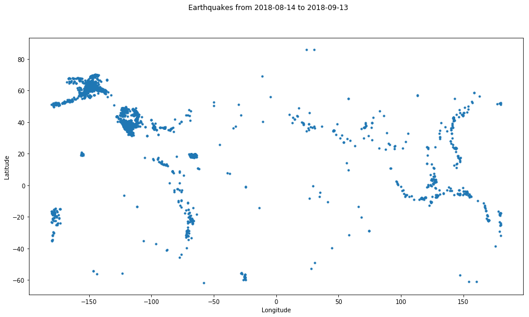

```python
rounding_factor = 10
fig, ax = plt.subplots(figsize=(15,8))
plt.plot(np.round(df['longitude'].head(10000),rounding_factor),
         np.round(df['latitude'].head(10000),rounding_factor),
         linestyle='none', marker='.')
plt.suptitle('Earthquakes from ' + str(np.min(df['time']))[:10] + ' to ' + str(np.max(df['time']))[:10])
plt.xlabel('Longitude')
plt.ylabel('Latitude')
plt.show()
```

**Data preparation**

Clean up date and location to simplify context

```python
df = df.sort_values('time', ascending=True)
df['date'] = df['time'].str[0:10]
# only keep the columns needed
df = df[['date', 'latitude', 'longitude', 'depth', 'mag', 'place']]
# df['date'] = df['time'].str.split(', ', expand=True)
newdf = df['place'].str.split(', ', expand=True)
df['place'] = newdf[1]
df = df[['date', 'latitude', 'longitude', 'depth', 'mag', 'place']]

print('total locations:',len(set(df['place'])))

# calculate mean lat lon for simplified locations
df_coords = df[['place', 'latitude', 'longitude']]
df_coords = df_coords.groupby(['place'], as_index=False).mean()
df_coords = df_coords[['place', 'latitude', 'longitude']]

df = df[['date', 'depth', 'mag', 'place']]
df = pd.merge(left=df, right=df_coords, how='inner', on=['place'])
df.head()
```

```
total locations: 101
```

|  | date | depth | mag | place | latitude | longitude |
| --- | --- | --- | --- | --- | --- | --- |
| 0 | 2018-08-14 | 27.3 | 1.1 | Alaska | 65.233723 | -147.717393 |
| 1 | 2018-08-14 | 6.5 | 1.5 | Alaska | 65.233723 | -147.717393 |
| 2 | 2018-08-14 | 12.7 | 1.6 | Alaska | 65.233723 | -147.717393 |
| 3 | 2018-08-14 | 3.6 | 1.8 | Alaska | 65.233723 | -147.717393 |
| 4 | 2018-08-14 | 5.1 | 1.4 | Alaska | 65.233723 | -147.717393 |

```python
print(set(df['place']))
```

[output not shown]

**Feature engineering**

```python
eq_tmp = df.copy()

DAYS_OUT_TO_PREDICT = 5

# loop through each zone and apply MA
eq_data = []
eq_data_last_days_out = []
for place in list(set(eq_tmp['place'])):
    temp_df = eq_tmp[eq_tmp['place'] == place].copy()
    temp_df['depth_avg_20'] = temp_df['depth'].rolling(window=20,center=False).mean()
    temp_df['depth_avg_10'] = temp_df['depth'].rolling(window=10,center=False).mean()
    temp_df['depth_avg_5'] = temp_df['depth'].rolling(window=5,center=False).mean()
    temp_df['mag_avg_20'] = temp_df['mag'].rolling(window=20,center=False).mean()
    temp_df['mag_avg_10'] = temp_df['mag'].rolling(window=10,center=False).mean()
    temp_df['mag_avg_5'] = temp_df['mag'].rolling(window=5,center=False).mean()
    temp_df.loc[:, 'mag_outcome'] = temp_df.loc[:, 'mag_avg_5'].shift(DAYS_OUT_TO_PREDICT * -1)

    eq_data_last_days_out.append(temp_df.tail(DAYS_OUT_TO_PREDICT))

    eq_data.append(temp_df)

# concat all location-based dataframes into master dataframe
import pandas as pd
eq_all = pd.concat(eq_data)

# remove any NaN fields
eq_all = eq_all[np.isfinite(eq_all['depth_avg_20'])]
eq_all = eq_all[np.isfinite(eq_all['mag_avg_20'])]
eq_all = eq_all[np.isfinite(eq_all['mag_outcome'])]
```

**Visualize locations**

List locations and plot our simplified set of geo-coords

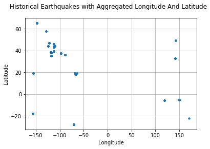

```python
plt.plot(eq_all['longitude'],
         eq_all['latitude'],
         linestyle='none', marker='.')
plt.suptitle('Historical Earthquakes with Aggregated Longitude And Latitude')
plt.xlabel('Longitude')
plt.ylabel('Latitude')
plt.grid()
plt.show()
```

**Prep live data**

```python
# keep our live data for predictions
eq_data_last_days_out = pd.concat(eq_data_last_days_out)
eq_data_last_days_out = eq_data_last_days_out[np.isfinite(eq_data_last_days_out['mag_avg_20'])]
```

**Set outcome variable**

```python
eq_all['mag_outcome'] = np.where(eq_all['mag_outcome'] > 2.5, 1,0)
print(eq_all['mag_outcome'].describe())
```

```
count    10362.000000
mean         0.063115
std          0.243182
min          0.000000
25%          0.000000
50%          0.000000
75%          0.000000
max          1.000000
Name: mag_outcome, dtype: float64
```

**Model data and check AUC score**

For more information on xgboost, check out the docs at: https://xgboost.readthedocs.io/en/latest/. For more information on the AUC score, see https://en.wikipedia.org/wiki/Receiver_operating_characteristic.

```python
import xgboost as xgb
from sklearn.model_selection import train_test_split
features = [f for f in list(eq_all) if f not in ['date', 'lon_box_mean',
 'lat_box_mean', 'mag_outcome', 'mag', 'place',
 'combo_box_mean',  'latitude',
 'longitude']]

X_train, X_test, y_train, y_test = train_test_split(eq_all[features],
                     eq_all['mag_outcome'], test_size=0.3, random_state=42)

dtrain = xgb.DMatrix(X_train[features], label=y_train)
dtest = xgb.DMatrix(X_test[features], label=y_test)

param = {
        'objective': 'binary:logistic',
        'booster': 'gbtree',
        'eval_metric': 'auc',
        'max_depth': 3,  # the maximum depth of each tree
        'eta': 0.1,  # the training step for each iteration
        'silent': 1}  # logging mode - quiet}  # the number of classes that exist in this datset

num_round = 500  # the number of training iterations
early_stopping_rounds=30
bst = xgb.train(param, dtrain, num_round) #, early_stopping_rounds=early_stopping_rounds)

preds = bst.predict(dtest)
np.mean(preds)
from sklearn.metrics import precision_score
from sklearn.metrics import roc_curve, auc

#print (auc(y_test, preds))
fpr, tpr, _ = roc_curve(y_test, preds)
roc_auc = auc(fpr, tpr)
print('AUC:', np.round(roc_auc,2))
```

```
AUC: 0.95
```

**Check variable importance - who is contributing the most to the score**

```python
def get_xgb_imp(xgb, feat_names):
    imp_vals = xgb.get_fscore()
    feats_imp = pd.DataFrame(imp_vals,index=np.arange(2)).T
    feats_imp.iloc[:,0]= feats_imp.index
    feats_imp.columns=['feature','importance']
    feats_imp.sort_values('importance',inplace=True,ascending=False)
    feats_imp.reset_index(drop=True,inplace=True)
    return feats_imp

feature_importance_df = get_xgb_imp(bst, features)
feature_importance_df
```

|  | feature | importance |
| --- | --- | --- |
| 0 | depth_avg_10 | 522 |
| 1 | depth_avg_20 | 518 |
| 2 | mag_avg_20 | 399 |
| 3 | depth_avg_5 | 393 |
| 4 | mag_avg_5 | 354 |
| 5 | mag_avg_10 | 338 |
| 6 | depth | 331 |

**Predict on live data**

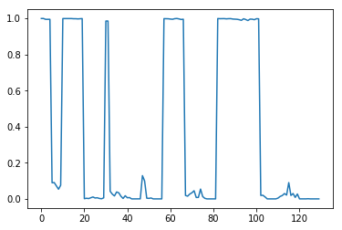

```python
# train on live data
dlive = xgb.DMatrix(eq_data_last_days_out[features]) #, label=[])
preds = bst.predict(dlive)

plt.plot(preds)
plt.show()
```

Create final data set with predictions per period (we will assume that these are days to simplify things - though not actual days)

```python
live_set = eq_data_last_days_out[['date', 'place', 'latitude', 'longitude']]
live_set.loc[:,'quake'] = preds
# aggregate down dups
live_set = live_set.groupby(['date', 'place'], as_index=False).mean()

# increment date to include DAYS_OUT_TO_PREDICT
live_set['date']= pd.to_datetime(live_set['date'],format='%Y-%m-%d')
live_set['date'] = live_set['date'] + pd.to_timedelta(DAYS_OUT_TO_PREDICT,unit='d')

live_set.head()
```

|  | date | place | latitude | longitude | quake |
| --- | --- | --- | --- | --- | --- |
| 0 | 2018-09-10 | Russia | 49.294476 | 142.672486 | 0.997976 |
| 1 | 2018-09-12 | Chile | -27.848584 | -70.792024 | 0.998398 |
| 2 | 2018-09-12 | Fiji | -18.191573 | -156.023480 | 0.998889 |
| 3 | 2018-09-12 | Idaho | 43.347477 | -112.525927 | 0.002360 |
| 4 | 2018-09-12 | Iran | 32.608062 | 49.524157 | 0.985235 |

```python
# see how our map will look using probability intensities
days = list(set([d for d in live_set['date'].astype(str) if d > dt.datetime.today().strftime('%Y-%m-%d')]))
days.sort()
days

predict_day = days[1]
```

**Shot predictions and use probability to highlight the quake's size**

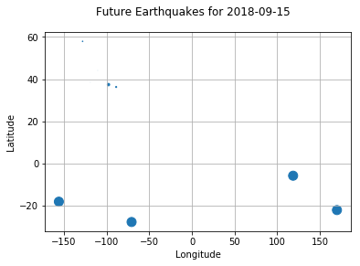

```python
live_set_tmp = live_set[live_set['date'] == predict_day]
plt.scatter(live_set_tmp['longitude'],
         live_set_tmp['latitude'], s=(live_set_tmp['quake'] * 100))
plt.suptitle('Future Earthquakes for ' + predict_day)
plt.xlabel('Longitude')
plt.ylabel('Latitude')
plt.grid()
plt.show()
```

**Abstracting Code Into Functions For Our Web Appliction**

Here we want to package all the above code into a few functions to make thing easier to impolement, run, and debug. The "prepare_earthquake_data_and_model()" function will do everything we did above up to predicting earthquakes on the live data. This is only run when the server is started or restared.

The "get_earth_quake_estimates()" function is called whenever the user moves the slider and will yeild a new set of geo-coordinates with earthquake activity for that day.

```python
import xgboost as xgb

def prepare_earthquake_data_and_model(days_out_to_predict = 5, max_depth=3, eta=0.1):
    import pandas as pd
    import numpy as np
    # get latest data from USGS servers
    df = pd.read_csv('https://earthquake.usgs.gov/earthquakes/feed/v1.0/summary/all_month.csv')
    df = df.sort_values('time', ascending=True)
    # truncate time from datetime
    df['date'] = df['time'].str[0:10]

    # only keep the columns needed
    df = df[['date', 'latitude', 'longitude', 'depth', 'mag', 'place']]
    temp_df = df['place'].str.split(', ', expand=True)
    df['place'] = temp_df[1]
    df = df[['date', 'latitude', 'longitude', 'depth', 'mag', 'place']]

    # calculate mean lat lon for simplified locations
    df_coords = df[['place', 'latitude', 'longitude']]
    df_coords = df_coords.groupby(['place'], as_index=False).mean()
    df_coords = df_coords[['place', 'latitude', 'longitude']]

    df = df[['date', 'depth', 'mag', 'place']]
    df = pd.merge(left=df, right=df_coords, how='inner', on=['place'])

    # loop through each zone and apply MA
    eq_data = []
    df_live = []
    for symbol in list(set(df['place'])):
        temp_df = df[df['place'] == symbol].copy()
        temp_df['depth_avg_20'] = temp_df['depth'].rolling(window=20,center=False).mean()
        temp_df['depth_avg_10'] = temp_df['depth'].rolling(window=10,center=False).mean()
        temp_df['depth_avg_5'] = temp_df['depth'].rolling(window=5,center=False).mean()
        temp_df['mag_avg_20'] = temp_df['mag'].rolling(window=20,center=False).mean()
        temp_df['mag_avg_10'] = temp_df['mag'].rolling(window=10,center=False).mean()
        temp_df['mag_avg_5'] = temp_df['mag'].rolling(window=5,center=False).mean()
        temp_df.loc[:, 'mag_outcome'] = temp_df.loc[:, 'mag_avg_5'].shift(days_out_to_predict * -1)

        df_live.append(temp_df.tail(days_out_to_predict))

        eq_data.append(temp_df)

    # concat all location-based dataframes into master dataframe
    df = pd.concat(eq_data)

    # remove any NaN fields
    df = df[np.isfinite(df['depth_avg_20'])]
    df = df[np.isfinite(df['mag_avg_20'])]
    df = df[np.isfinite(df['mag_outcome'])]

    # prepare outcome variable
    df['mag_outcome'] = np.where(df['mag_outcome'] > 2.5, 1,0)

    df = df[['date',
             'latitude',
             'longitude',
             'depth_avg_20',
             'depth_avg_10',
             'depth_avg_5',
             'mag_avg_20',
             'mag_avg_10',
             'mag_avg_5',
             'mag_outcome']]

    # keep only data where we can make predictions
    df_live = pd.concat(df_live)
    df_live = df_live[np.isfinite(df_live['mag_avg_20'])]

    # let's train the model whenever the webserver is restarted
    from sklearn.model_selection import train_test_split
    features = [f for f in list(df) if f not in ['date', 'mag_outcome', 'latitude',
     'longitude']]

    X_train, X_test, y_train, y_test = train_test_split(df[features],
                         df['mag_outcome'], test_size=0.3, random_state=42)

    dtrain = xgb.DMatrix(X_train[features], label=y_train)
    dtest = xgb.DMatrix(X_test[features], label=y_test)

    param = {
            'objective': 'binary:logistic',
            'booster': 'gbtree',
            'eval_metric': 'auc',
            'max_depth': max_depth,  # the maximum depth of each tree
            'eta': eta,  # the training step for each iteration
            'silent': 1}  # logging mode - quiet}  # the number of classes that exist in this datset

    num_round = 500  # the number of training iterations
    early_stopping_rounds=30
    xgb_model = xgb.train(param, dtrain, num_round)


    # train on live data
    dlive = xgb.DMatrix(df_live[features])
    preds = xgb_model.predict(dlive)

    # add preds to live data
    df_live = df_live[['date', 'place', 'latitude', 'longitude']]
    # add predictions back to dataset
    df_live = df_live.assign(preds=pd.Series(preds).values)

    # aggregate down dups
    df_live = df_live.groupby(['date', 'place'], as_index=False).mean()

    # increment date to include DAYS_OUT_TO_PREDICT
    df_live['date']= pd.to_datetime(df_live['date'],format='%Y-%m-%d')
    df_live['date'] = df_live['date'] + pd.to_timedelta(days_out_to_predict,unit='d')

    return(df_live)

df_live = prepare_earthquake_data_and_model()
df_live.tail()
```

[output not shown]

```python
from datetime import datetime
datetime_object = datetime.strptime("09/14/2018", '%m/%d/%Y')
list(set([d for d in df_live['date'] if d == datetime_object]))
```

```
[Timestamp('2018-09-14 00:00:00')]
```

**Format predictions into a format that Google Maps can understand**

```python
def get_earth_quake_estimates(desired_date, df_live):
    from datetime import datetime
    datetime_object = desired_date #datetime.strptime(desired_date, '%m/%d/%Y')
    live_set_tmp = df_live[df_live['date'] == datetime_object]

    # format lat/lons like Google Maps expects
    LatLngString = ''
    if (len(live_set_tmp) > 0):
        for lat, lon, pred in zip(live_set_tmp['latitude'], live_set_tmp['longitude'], live_set_tmp['preds']):
            # this is the threashold of probability to decide what to show and what not to show
            if (pred > 0.3):
                LatLngString += "new google.maps.LatLng(" + str(lat) + "," + str(lon) + "),"

    return(LatLngString)

get_earth_quake_estimates(datetime.strptime("09/16/2018", '%m/%d/%Y'), df_live)
```

```
'new google.maps.LatLng(-18.191572881355913,-156.02348022598878),new google.maps.LatLng(-5.870824218749997,118.55905859375),new google.maps.LatLng(33.06068266666666,141.183776),new google.maps.LatLng(-5.327680000000001,150.22351999999998),'
```

```python
# pull future predictions
from datetime import timedelta
horizon_date = datetime.today() + timedelta(days=0)
print(str(horizon_date)[:10])
get_earth_quake_estimates(str(horizon_date)[:10], df_live)
```

```
2018-09-13
```

```
'new google.maps.LatLng(19.199355555555556,-64.64806666666668),new google.maps.LatLng(-22.180607692307696,169.9437615384616),new google.maps.LatLng(-5.327680000000001,150.22351999999998),'
```

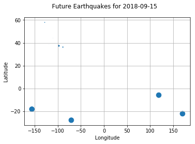

```python
# train on live data
dlive = xgb.DMatrix(eq_data_last_days_out[features]) #, label=[])

preds = bst.predict(dlive)
# see how our map will look using probability intensities
days = list(set([d for d in live_set['date'].astype(str) if d > dt.datetime.today().strftime('%Y-%m-%d')]))
days.sort()
predict_day = days[1]


live_set_tmp = live_set[live_set['date'] == predict_day]
plt.scatter(live_set_tmp['longitude'],
         live_set_tmp['latitude'], s=(live_set_tmp['quake'] * 100))
plt.suptitle('Future Earthquakes for ' + predict_day)
plt.xlabel('Longitude')
plt.ylabel('Latitude')
plt.grid()
plt.show()
```

**Google Maps**

You will need to create a free [Google Maps API Key](https://developers.google.com/maps/documentation/javascript/get-api-key). In this project, we're going to introduce some really cool front-end tools like Ajax, Google Maps, and on-the-fly predictions.

The skeleton will be a little like the pervious project of having one "main.py" web-serving Python file that will prepare data and data model adn will also control web content. We will also have on additional folder called 'template' to hold the web template.

**Worldwide Earthquake Forecaster**

A look at our final product:

[figure not shown]

# Flask Source Code

We wil work with only two files - main.py and index.html. Create the following folder structure:

```
earthquake-forecaster/
├── main.py
└── templates/
    └── index.html
```

**main.py source code**

```
#!/usr/bin/env python
from flask import Flask, render_template, flash, request
import logging, io, base64, os, datetime
from datetime import datetime
from datetime import timedelta
import pandas as pd
import numpy as np
import xgboost as xgb

# global variables
earthquake_live = None
days_out_to_predict = 5


app = Flask(__name__)

def prepare_earthquake_data_and_model(days_out_to_predict = 5, max_depth=3, eta=0.1):
    import pandas as pd
    import numpy as np
    # get latest data from USGS servers
    df = pd.read_csv('https://earthquake.usgs.gov/earthquakes/feed/v1.0/summary/all_month.csv')
    df = df.sort_values('time', ascending=True)
    # truncate time from datetime
    df['date'] = df['time'].str[0:10]

    # only keep the columns needed
    df = df[['date', 'latitude', 'longitude', 'depth', 'mag', 'place']]
    temp_df = df['place'].str.split(', ', expand=True)
    df['place'] = temp_df[1]
    df = df[['date', 'latitude', 'longitude', 'depth', 'mag', 'place']]

    # calculate mean lat lon for simplified locations
    df_coords = df[['place', 'latitude', 'longitude']]
    df_coords = df_coords.groupby(['place'], as_index=False).mean()
    df_coords = df_coords[['place', 'latitude', 'longitude']]

    df = df[['date', 'depth', 'mag', 'place']]
    df = pd.merge(left=df, right=df_coords, how='inner', on=['place'])

    # loop through each zone and apply MA
    eq_data = []
    df_live = []
    for symbol in list(set(df['place'])):
        temp_df = df[df['place'] == symbol].copy()
        temp_df['depth_avg_20'] = temp_df['depth'].rolling(window=20,center=False).mean()
        temp_df['depth_avg_10'] = temp_df['depth'].rolling(window=10,center=False).mean()
        temp_df['depth_avg_5'] = temp_df['depth'].rolling(window=5,center=False).mean()
        temp_df['mag_avg_20'] = temp_df['mag'].rolling(window=20,center=False).mean()
        temp_df['mag_avg_10'] = temp_df['mag'].rolling(window=10,center=False).mean()
        temp_df['mag_avg_5'] = temp_df['mag'].rolling(window=5,center=False).mean()
        temp_df.loc[:, 'mag_outcome'] = temp_df.loc[:, 'mag_avg_5'].shift(days_out_to_predict * -1)

        df_live.append(temp_df.tail(days_out_to_predict))

        eq_data.append(temp_df)

    # concat all location-based dataframes into master dataframe
    df = pd.concat(eq_data)

    # remove any NaN fields
    df = df[np.isfinite(df['depth_avg_20'])]
    df = df[np.isfinite(df['mag_avg_20'])]
    df = df[np.isfinite(df['mag_outcome'])]

    # prepare outcome variable
    df['mag_outcome'] = np.where(df['mag_outcome'] > 2.5, 1,0)

    df = df[['date',
             'latitude',
             'longitude',
             'depth_avg_20',
             'depth_avg_10',
             'depth_avg_5',
             'mag_avg_20',
             'mag_avg_10',
             'mag_avg_5',
             'mag_outcome']]

    # keep only data where we can make predictions
    df_live = pd.concat(df_live)
    df_live = df_live[np.isfinite(df_live['mag_avg_20'])]

    # let's train the model whenever the webserver is restarted
    from sklearn.model_selection import train_test_split
    features = [f for f in list(df) if f not in ['date', 'mag_outcome', 'latitude',
     'longitude']]

    X_train, X_test, y_train, y_test = train_test_split(df[features],
                         df['mag_outcome'], test_size=0.3, random_state=42)

    dtrain = xgb.DMatrix(X_train[features], label=y_train)
    dtest = xgb.DMatrix(X_test[features], label=y_test)

    param = {
            'objective': 'binary:logistic',
            'booster': 'gbtree',
            'eval_metric': 'auc',
            'max_depth': max_depth,  # the maximum depth of each tree
            'eta': eta,  # the training step for each iteration
            'silent': 1}  # logging mode - quiet}  # the number of classes that exist in this datset

    num_round = 500  # the number of training iterations
    early_stopping_rounds=30
    xgb_model = xgb.train(param, dtrain, num_round)


    # train on live data
    dlive = xgb.DMatrix(df_live[features])
    preds = xgb_model.predict(dlive)

    # add preds to live data
    df_live = df_live[['date', 'place', 'latitude', 'longitude']]
    # add predictions back to dataset
    df_live = df_live.assign(preds=pd.Series(preds).values)

    # aggregate down dups
    df_live = df_live.groupby(['date', 'place'], as_index=False).mean()

    # increment date to include DAYS_OUT_TO_PREDICT
    df_live['date']= pd.to_datetime(df_live['date'],format='%Y-%m-%d')
    df_live['date'] = df_live['date'] + pd.to_timedelta(days_out_to_predict,unit='d')

    return(df_live)

def get_earth_quake_estimates(desired_date, df_live):
    from datetime import datetime
    live_set_tmp = df_live[df_live['date'] == desired_date]

    # format lat/lons like Google Maps expects
    LatLngString = ''
    if (len(live_set_tmp) > 0):
        for lat, lon, pred in zip(live_set_tmp['latitude'], live_set_tmp['longitude'], live_set_tmp['preds']):
            # this is the threashold of probability to decide what to show and what not to show
            if (pred > 0.3):
                LatLngString += "new google.maps.LatLng(" + str(lat) + "," + str(lon) + "),"

    return(LatLngString)


@app.before_first_request
def startup():
    global earthquake_live

    # prepare earthquake data, model and get live data set with earthquake forecasts
    earthquake_live = prepare_earthquake_data_and_model()


@app.route("/", methods=['POST', 'GET'])
def build_page():
        if request.method == 'POST':

            horizon_int = int(request.form.get('slider_date_horizon'))
            horizon_date = datetime.today() + timedelta(days=horizon_int)

            return render_template('index.html',
                date_horizon = horizon_date.strftime('%m/%d/%Y'),
                earthquake_horizon = get_earth_quake_estimates(str(horizon_date)[:10], earthquake_live),
                current_value=horizon_int,
                days_out_to_predict=days_out_to_predict)

        else:
            # set blank map
            return render_template('index.html',
                date_horizon = datetime.today().strftime('%m/%d/%Y'),
                earthquake_horizon = '',
                current_value=0,
                days_out_to_predict=days_out_to_predict)



if __name__=='__main__':
    app.run(debug=True)
```

**template/index.html source code**

```
<!DOCTYPE html>
<html>
<head>
    <meta name="viewport" content="width=device-width, initial-scale=1">
    <meta charset="UTF=8">
    <title>Predicting Earthquakes</title>
    <script src="//ajax.googleapis.com/ajax/libs/jquery/3.3.1/jquery.min.js"></script>
  <link rel="stylesheet" href="//netdna.bootstrapcdn.com/bootstrap/3.0.3/css/bootstrap-theme.min.css">
    <link rel="stylesheet" href="//netdna.bootstrapcdn.com/bootstrap/3.0.3/css/bootstrap.min.css">
    <script src="//netdna.bootstrapcdn.com/bootstrap/3.0.3/js/bootstrap.min.js"></script>

    <script async defer
        src="https://maps.googleapis.com/maps/api/js?key= <<YOUR_KEY_HERE>>&libraries=visualization&callback=initMap">
    </script>

    <style>
      /* Always set the map height explicitly to define the size of the div
       * element that contains the map. */
      #map {
        height: 50%;
        width: 700px;
      }
      /* Optional: Makes the sample page fill the window. */
      html, body {
        height: 100%;
        margin: 0;
        padding: 0;
      }
      #floating-panel {
        position: absolute;
        top: 10px;
        left: 25%;
        z-index: 5;
        background-color: #fff;
        padding: 5px;
        border: 1px solid #999;
        text-align: center;
        font-family: 'Roboto','sans-serif';
        line-height: 30px;
        padding-left: 10px;
      }
      #floating-panel {
        background-color: #fff;
        border: 1px solid #999;
        left: 25%;
        padding: 5px;
        position: absolute;
        top: 10px;
        z-index: 5;
      }
    </style>
  </head>

  <body>
        <table border=0 cellpadding="1" style="width: 700px; background-color:black;">
            <tr>
              <td><h1><p style="text-align:center"><font color="white">Worldwide Earthquake Forecaster</font></p></h1></td>
            </tr>
        </table>


    <div id="map"></div>
    <script>

      var map, heatmap;

      function initMap() {
        map = new google.maps.Map(document.getElementById('map'), {
          zoom: 1.5,
          center: {lat: 0, lng: 0},
          mapTypeId: 'roadmap'
        });

        heatmap = new google.maps.visualization.HeatmapLayer({
          data: getPoints(),
          map: map
        });
      }

      function toggleHeatmap() {
        heatmap.setMap(heatmap.getMap() ? null : map);
      }

      function changeGradient() {
        var gradient = [
          'rgba(0, 255, 255, 0)',
          'rgba(0, 255, 255, 1)',
          'rgba(0, 191, 255, 1)',
          'rgba(0, 127, 255, 1)',
          'rgba(0, 63, 255, 1)',
          'rgba(0, 0, 255, 1)',
          'rgba(0, 0, 223, 1)',
          'rgba(0, 0, 191, 1)',
          'rgba(0, 0, 159, 1)',
          'rgba(0, 0, 127, 1)',
          'rgba(63, 0, 91, 1)',
          'rgba(127, 0, 63, 1)',
          'rgba(191, 0, 31, 1)',
          'rgba(255, 0, 0, 1)'
        ]
        heatmap.set('gradient', heatmap.get('gradient') ? null : gradient);
      }

      // Heatmap data
      function getPoints() {
        return [{{earthquake_horizon}}];
      }
    </script>

        <table border=1 cellpadding="1" style="width: 700px; background-color:black;">
            <tr>
                <td><p style="text-align:center">
                  <form id='submit_params' method="POST" action="{{ url_for('build_page') }}">
                    <div class="slidecontainer" style='width: 100%;'>
                    <label><font color="white">Select future date: <span id="label_slider_value">{{date_horizon}}</span></font></label><BR>
                    <input type="range" min="0" max="{{days_out_to_predict}}" value="{{current_value}}" name="slider_date_horizon"
                      id="slider_date_horizon" step="1" style='width: 100%;'>
                  </div>
                </form>
             </td>
          </tr>
      </table>


     <script>
        // Slider logic
        var slider1 = document.getElementById("slider_date_horizon");
        var output1 = document.getElementById("label_slider_value");

          slider1.onmouseup = function () {
            document.getElementById("submit_params").submit();
          }

        slider1.oninput = function() {
            var horizon_date = new Date();
            horizon_date.setDate(horizon_date.getDate() + Math.trunc(parseInt(this.value)));
            output1.innerHTML = (horizon_date.getMonth()+1) + "/" + horizon_date.getDate() + "/" + horizon_date.getFullYear(); //this.value;

        }

     </script>
    </body>
</html>
```

# PythonAnywhere

You will need to bash/console install one Python library on PythonAnywhere:

```
pip3 install scikit-learn --user
```

Follow the video for the rest of the upload and build information.

Best!